# Solid fuels model — monthly BVAR-SV-outlier

This notebook estimates the solid fuels component of the energy-inflation suite. The endogenous block contains monthly absolute changes in wholesale natural-gas prices, PPI Energy and the HICP solid fuels index. The model uses 12 lags and no deterministic seasonal regressors.

## 1. Imports and configuration

```python
from pathlib import Path
import sys

import numpy as np
import pandas as pd
import matplotlib.pyplot as plt
from IPython.display import display


def find_project_root(start: Path) -> Path:
    start = start.resolve()
    for candidate in [start, *start.parents]:
        if (candidate / "data").exists() or (candidate / "src").exists():
            return candidate
    return start


PROJECT_ROOT = find_project_root(Path.cwd())
MODEL_DIR_CANDIDATES = [
    PROJECT_ROOT / "src" / "model",
    PROJECT_ROOT,
    Path.cwd(),
]
for candidate in MODEL_DIR_CANDIDATES:
    required_modules = (
        "energy_bvar_model.py",
        "energy_bvar_monthly_hicp.py",
        "energy_bvar_plot.py",
        "energy_bvar_io.py",
    )
    if all((candidate / name).exists() for name in required_modules):
        sys.path.insert(0, str(candidate))
        MODEL_DIR = candidate
        break
else:
    raise FileNotFoundError(
        "Place energy_bvar_model.py, energy_bvar_monthly_hicp.py, "
        "energy_bvar_plot.py and energy_bvar_io.py beside this notebook "
        "or in src/model/."
    )

from energy_bvar_model import (
    BVARSVOPriorConfig,
    SamplerConfig,
    coefficient_posterior_tables,
    forecast_bvar_sv_outlier,
    forecast_error_variance_decomposition,
    forecast_horizon_table,
    historical_decomposition,
    impulse_responses,
    make_bvar_svo_prior,
    mcmc_diagnostics,
    nowcast_summary_table,
    path_horizon_table,
    posterior_outlier_probability,
    posterior_predictive_statistics,
    prepare_bvar_panel,
    residual_diagnostic_table,
    run_energy_bvar,
    stability_diagnostics,
    stationarity_tests,
)
from energy_bvar_io import save_energy_bvar_result
from energy_bvar_monthly_hicp import (
    forecast_hicp_component,
    load_monthly_hicp_component_panel,
    monthly_hicp_component_spec,
    monthly_hicp_series_construction_table,
)
from energy_bvar_plot import (
    format_number,
    plot_absolute_differences,
    plot_chain_acf_grid,
    plot_coefficient_heatmap,
    plot_data_levels,
    plot_fevd,
    plot_forecast_comparison,
    plot_hicp_forecast_fan,
    plot_historical_decomposition,
    plot_impulse_responses,
    plot_minnesota_prior_by_equation,
    plot_nowcast_fan,
    plot_phi_and_outlier_priors,
    plot_posterior_predictive_check,
    plot_short_forecast_fan,
    plot_shrinkage_comparison,
    plot_spectral_radius,
    plot_standardized_residuals,
    plot_trace_grid,
    plot_volatility_decomposition,
    style_numeric_table,
)

pd.set_option("display.max_rows", 180)
pd.set_option("display.max_columns", 50)
pd.set_option("display.width", 180)
plt.rcParams.update({
    "figure.dpi": 120,
    "axes.titlesize": 11,
    "axes.labelsize": 10,
    "legend.fontsize": 9,
})

COMPONENT = "solid_fuels"
SPEC = monthly_hicp_component_spec(COMPONENT)
SEED = 42
P = 12
VARIABLES = SPEC["variables"]
TARGET = SPEC["target"]
UNITS = SPEC["units"]
SAVE_RESULTS = False
RESULTS_ROOT = PROJECT_ROOT / "results"

print(f"Project root: {PROJECT_ROOT}")
print(f"Model modules: {MODEL_DIR}")
print(f"Component: {COMPONENT}")
```

```
Project root: C:\Users\kelyan.gane\Project\Python\Bayesian_model\bvar-energy
Model modules: C:\Users\kelyan.gane\Project\Python\Bayesian_model\bvar-energy\src\model
Component: solid_fuels
```

## 2. Data

```
Dataset: C:\Users\kelyan.gane\Project\Python\Bayesian_model\bvar-energy\data\processed\20260805\solid_fuels_monthly.csv
Sample calendar: 1996-01-01 to 2026-08-01
```

Construction of the solid fuels-model level series

|  | series_type | model_unit | source_inputs | construction | note |
| --- | --- | --- | --- | --- | --- |
| natural_gas_wholesale | chain-linked wholesale price | EUR/MWh | Bloomberg TTF; World Bank Natural gas, Europe; EUR/USD | Bloomberg TTF monthly mean; earlier months backcast with the World Bank Natural gas, Europe proxy via backward chain-linking. The proxy level is pinned to TTF at the anchor month; no overlap window an… | The paper uses Energy Intelligence European border gas. World Bank Natural gas, Europe is the public substitute and belongs to the same European border/import-price family. TTF anchor month: 2011-02-0… |
| ppi_energy | producer-price index | Index | Haver PPI Energy (H025PP@G10) | Monthly Haver level; no source-stage transformation. | The notebook applies an absolute monthly difference before estimation. |
| hicp_solid_fuels | consumer-price index | HICP index | Haver HICP solid fuels (H023HW54@EUDATA) | Monthly Haver level; no tax reconstruction is applied. | The notebook forecasts the HICP level directly and derives YoY inflation ex post. |

Latest processed levels

| date | natural_gas_wholesale | ppi_energy | hicp_solid_fuels |
| --- | --- | --- | --- |
| 2025-09-01 | 32.02 | 124.03 | 99.41 |
| 2025-10-01 | 32.04 | 123.81 | 100.40 |
| 2025-11-01 | 30.66 | 124.13 | 101.86 |
| 2025-12-01 | 27.42 | 123.82 | 102.41 |
| 2026-01-01 | 34.52 | 124.32 | 103.36 |
| 2026-02-01 | 32.51 | 123.74 | 105.06 |
| 2026-03-01 | 52.63 | 128.65 | 105.92 |
| 2026-04-01 | 45.26 | 131.24 | 106.44 |
| 2026-05-01 | 47.34 | 131.96 | 106.38 |
| 2026-06-01 | 44.86 | — | 106.43 |
| 2026-07-01 | 53.97 | — | — |
| 2026-08-01 | 57.40 | — | — |

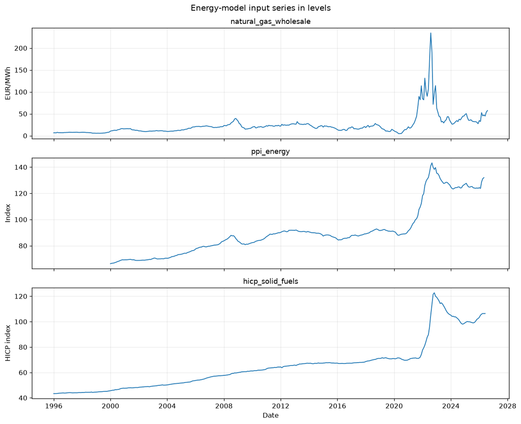

```python
# Set VINTAGE = "YYYYMMDD" to force one processed vintage.
VINTAGE = None
PROCESSED_ROOT = PROJECT_ROOT / "data" / "processed"

if VINTAGE is None:
    candidates = sorted(
        path for path in PROCESSED_ROOT.glob("*/solid_fuels_monthly.csv")
        if path.is_file()
    )
    if not candidates:
        raise FileNotFoundError(
            f"No solid_fuels_monthly.csv found below {PROCESSED_ROOT}."
        )
    COMPONENT_DATASET = candidates[-1]
else:
    COMPONENT_DATASET = PROCESSED_ROOT / VINTAGE / "solid_fuels_monthly.csv"

levels = load_monthly_hicp_component_panel(
    COMPONENT_DATASET,
    component=COMPONENT,
    variables=VARIABLES,
)

print(f"Dataset: {COMPONENT_DATASET}")
print(f"Sample calendar: {levels.index.min().date()} to {levels.index.max().date()}")

display(style_numeric_table(
    monthly_hicp_series_construction_table(COMPONENT_DATASET, COMPONENT),
    caption=f"Construction of the {SPEC['label']}-model level series",
))
display(style_numeric_table(
    levels.tail(12),
    caption="Latest processed levels",
))
plot_data_levels(levels, units=UNITS)
plt.show()
```

### Absolute monthly changes

The endogenous vector is ordered from upstream market prices to the consumer-price target:

$$ y_t = \begin{bmatrix} \Delta P_t^{\mathrm{gas}} \\ \Delta P_t^{\mathrm{PPI\ energy}} \\ \Delta HICP_t^{\mathrm{solid fuels}} \end{bmatrix}, \qquad \Delta x_t=x_t-x_{t-1}. $$

All three variables remain in absolute differences rather than log differences.

Transformation and estimation sample

|  | value |
| --- | --- |
| balanced_change_start | 2000-02-01 00:00:00 |
| balanced_change_end | 2026-05-01 00:00:00 |
| balanced_changes | 316 |
| VAR_regression_observations | 304 |
| regression_columns_per_equation | 37 |
| ragged_edge_months | 3 |
| latest_calendar_month | 2026-08-01 00:00:00 |

Ragged-edge absolute changes

| date | natural_gas_wholesale | ppi_energy | hicp_solid_fuels |
| --- | --- | --- | --- |
| 2026-06-01 | -2.48 | — | 0.05 |
| 2026-07-01 | 9.11 | — | — |
| 2026-08-01 | 3.43 | — | — |

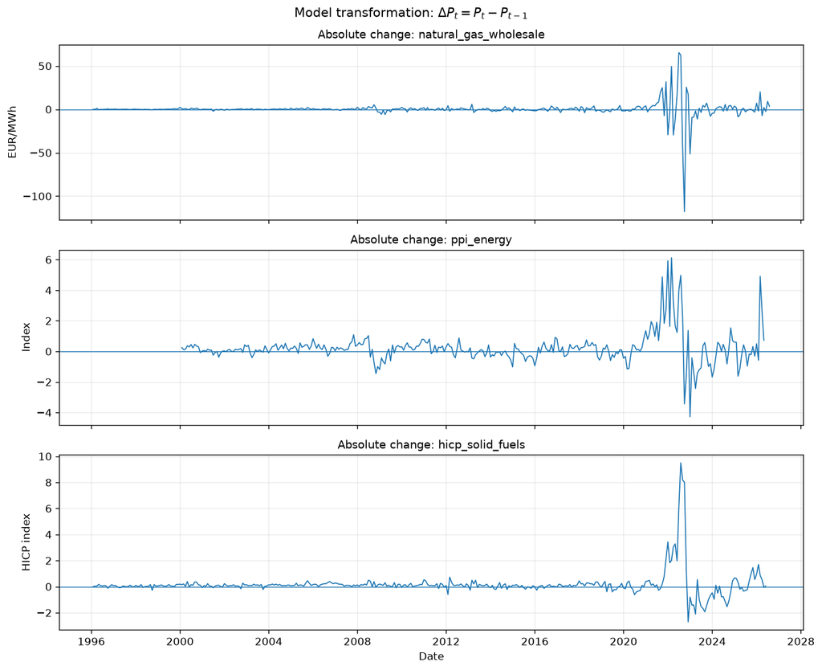

```python
prep = prepare_bvar_panel(
    levels,
    p=P,
    variables=VARIABLES,
)

transformation_summary = pd.Series({
    "balanced_change_start": prep["balanced_start"],
    "balanced_change_end": prep["balanced_end"],
    "balanced_changes": prep["n_balanced_changes"],
    "VAR_regression_observations": prep["n_regression_observations"],
    "regression_columns_per_equation": prep["k"],
    "ragged_edge_months": prep["n_ragged_months"],
    "latest_calendar_month": prep["last_calendar_date"],
})
display(style_numeric_table(
    transformation_summary.to_frame("value"),
    caption="Transformation and estimation sample",
))
display(style_numeric_table(
    prep["ragged"],
    caption="Ragged-edge absolute changes",
))
plot_absolute_differences(prep["differences"], units=UNITS)
plt.show()
```

## 3. Model

For $t=1,\ldots,T$, the model is

$$ y_t = c + \sum_{\ell=1}^{12} B_\ell y_{t-\ell} + \nu_t. $$

The residual covariance follows

$$ \nu_t=A^{-1}O_t\Lambda_t^{1/2}\varepsilon_t, \qquad \varepsilon_t\sim\mathcal N(0,I), $$

where the diagonal elements of $\Lambda_t$ follow independent log random walks and $O_t$ contains the transitory outlier scales.

## 4. Priors

Prior hyperparameters

|  | value | interpretation |
| --- | --- | --- |
| lambda1 | 0.20 | overall Minnesota lag tightness |
| lambda2 | 0.50 | additional cross-lag tightness |
| lambda3 | 1.00 | lag-decay exponent |
| lambda4 | 10.00 | constant prior scale |
| A prior variance | 10.00 | variance of each free contemporaneous A coefficient |
| phi prior mean | 0.02 | prior mean of volatility-of-volatility variance |
| outlier alpha | 2.50 | Beta outlier pseudo-count |
| outlier beta | 117.50 | Beta regular-observation pseudo-count |

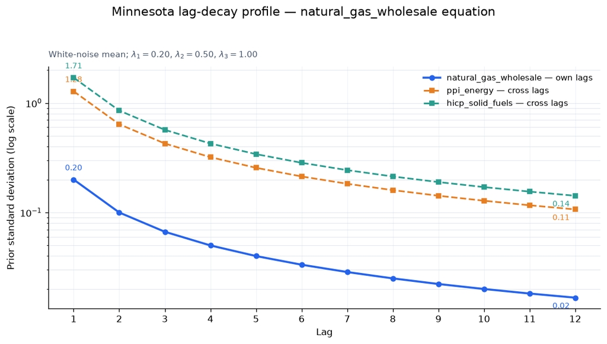

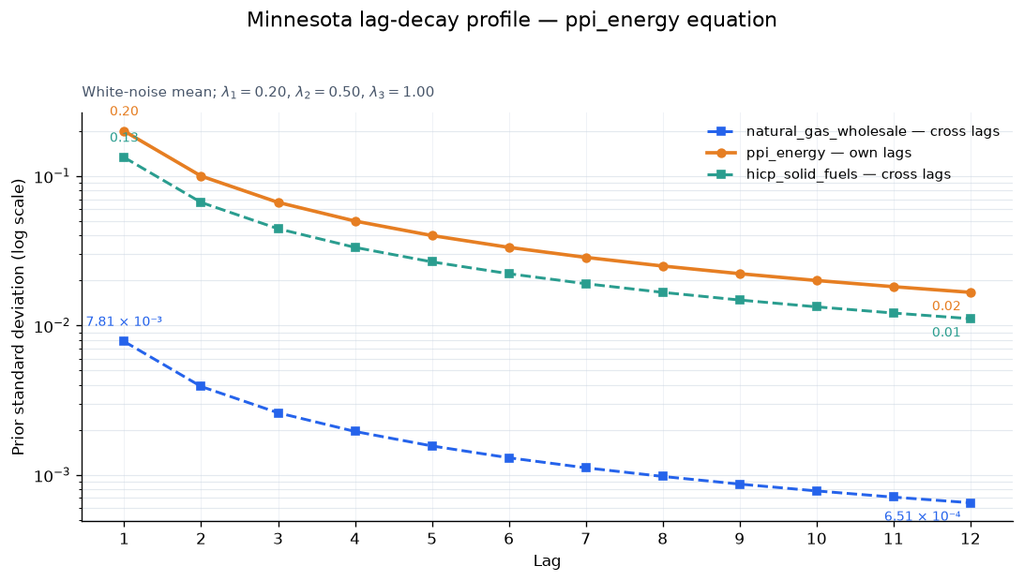

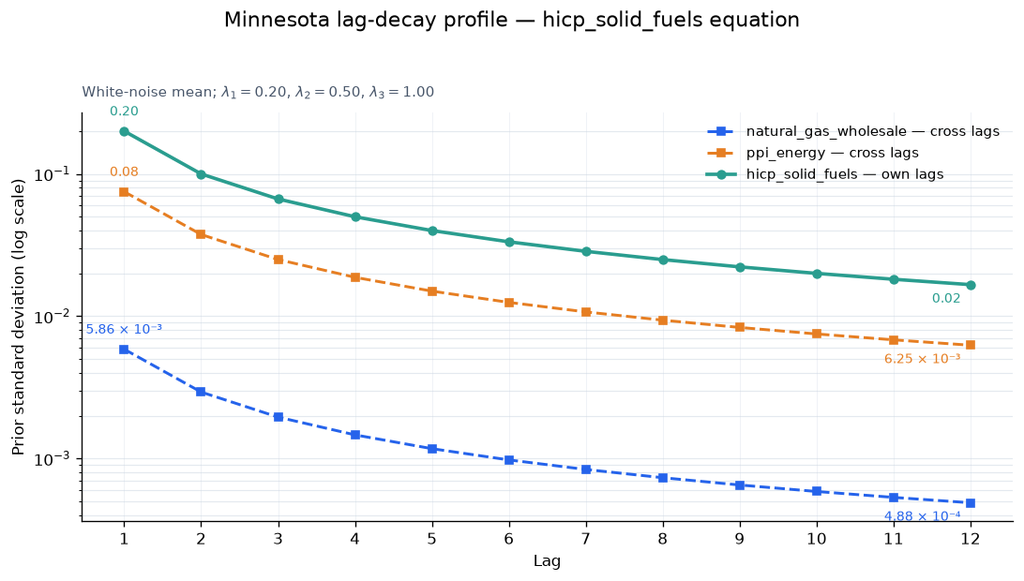

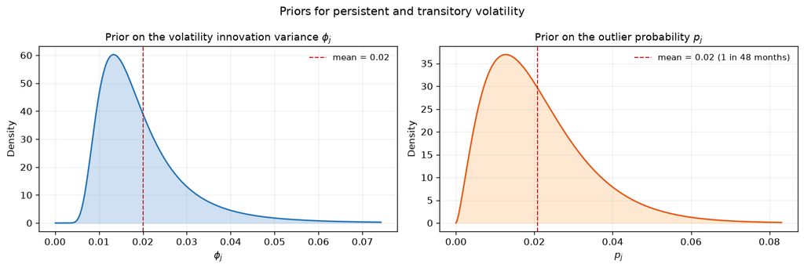

```python
prior_config = BVARSVOPriorConfig(
    lambda1=0.20,
    lambda2=0.50,
    lambda3=1.00,
    lambda4=10.0,
    a_prior_var=10.0,
    phi_prior_mean=0.02,
    phi_prior_df=10.0,
    h0_var=4.0,
    outlier_mean_frequency=1.0 / 48.0,
    outlier_prior_observations=120.0,
    outlier_grid_min=2.0,
    outlier_grid_max=20.0,
    outlier_grid_step=1.0,
    ksc_offset_scale=1e-6,
)
prior = make_bvar_svo_prior(prep, prior_config)

prior_table = pd.DataFrame({
    "value": [
        prior_config.lambda1,
        prior_config.lambda2,
        prior_config.lambda3,
        prior_config.lambda4,
        prior_config.a_prior_var,
        prior_config.phi_prior_mean,
        prior["outlier_alpha"],
        prior["outlier_beta"],
    ],
    "interpretation": [
        "overall Minnesota lag tightness",
        "additional cross-lag tightness",
        "lag-decay exponent",
        "constant prior scale",
        "variance of each free contemporaneous A coefficient",
        "prior mean of volatility-of-volatility variance",
        "Beta outlier pseudo-count",
        "Beta regular-observation pseudo-count",
    ],
}, index=[
    "lambda1", "lambda2", "lambda3", "lambda4",
    "A prior variance", "phi prior mean",
    "outlier alpha", "outlier beta",
])
display(style_numeric_table(prior_table, caption="Prior hyperparameters"))

prior_figures = plot_minnesota_prior_by_equation(prior, VARIABLES, P)
for equation, figure in prior_figures.items():
    display(figure)
    plt.close(figure)
plot_phi_and_outlier_priors(prior)
plt.show()
```

## 5. Posterior and Gibbs sampler

The coefficient block is drawn from its heteroskedastic Gaussian conditional and truncated to stable VAR dynamics. The contemporaneous matrix, complete stochastic-volatility paths, volatility innovation variances, outlier states and outlier probabilities are then updated conditionally inside each Gibbs iteration.

```python
sampler_config = SamplerConfig(
    reps=6_000,
    burn=3_000,
    thin=1,
    seed=SEED,
    max_stability_tries=1_000,
    progress_every=500,
)

result = run_energy_bvar(
    levels=levels,
    model_id=COMPONENT,
    vintage=COMPONENT_DATASET.parent.name,
    p=P,
    variables=VARIABLES,
    prior_config=prior_config,
    sampler_config=sampler_config,
    code_version="energy_bvar_model-exog-v1",
)

print(f"Retained posterior draws: {result['n_draws']:,}")
print(f"Run ID: {result['metadata']['run_id']}")
print(f"B instability proposal rejection rate: {result['B_instability_rejection_rate']:.2%}")
display(style_numeric_table(
    pd.Series(dict(zip(VARIABLES, result["ksc_offsets"]))).to_frame("KSC offset"),
    caption="Adaptive KSC offsets",
))

if SAVE_RESULTS:
    saved_result_paths = save_energy_bvar_result(result, RESULTS_ROOT)
    print(f"Saved run: {saved_result_paths['directory']}")
```

```
iteration 500/6,000 | B instability rejection 0.00% | radius 0.8726
iteration 1,000/6,000 | B instability rejection 0.00% | radius 0.8155
iteration 1,500/6,000 | B instability rejection 0.00% | radius 0.7882
iteration 2,000/6,000 | B instability rejection 0.00% | radius 0.8547
iteration 2,500/6,000 | B instability rejection 0.00% | radius 0.8581
iteration 3,000/6,000 | B instability rejection 0.00% | radius 0.8096
iteration 3,500/6,000 | B instability rejection 0.00% | radius 0.8693
iteration 4,000/6,000 | B instability rejection 0.00% | radius 0.8262
iteration 4,500/6,000 | B instability rejection 0.00% | radius 0.8837
iteration 5,000/6,000 | B instability rejection 0.00% | radius 0.8189
iteration 5,500/6,000 | B instability rejection 0.00% | radius 0.7700
iteration 6,000/6,000 | B instability rejection 0.00% | radius 0.8309
Retained posterior draws: 3,000
Run ID: 45ad9ed28f6414c3b2025dc9694d28b2b66fff6a40085a84ea43458668aeee57
B instability proposal rejection rate: 0.00%
```

Adaptive KSC offsets

|  | KSC offset |
| --- | --- |
| natural_gas_wholesale | 7.20 × 10⁻⁶ |
| ppi_energy | 6.86 × 10⁻⁸ |
| hicp_solid_fuels | 3.10 × 10⁻⁸ |

## 6. Results

### 6.1 Posterior coefficients

```
natural_gas_wholesale equation
```

Posterior coefficients — natural_gas_wholesale equation

| regressor | prior_mean | prior_sd | posterior_mean | posterior_median | posterior_sd | q05 | q16 | q84 | q95 | ESS |
| --- | --- | --- | --- | --- | --- | --- | --- | --- | --- | --- |
| const | 0.00 | 107.58 | -0.06 | -0.06 | 0.08 | -0.20 | -0.15 | 0.02 | 0.07 | 1418.79 |
| natural_gas_wholesale L1 | 0.00 | 0.20 | 9.79 × 10⁻⁴ | 4.08 × 10⁻⁴ | 0.06 | -0.09 | -0.05 | 0.06 | 0.09 | 957.50 |
| ppi_energy L1 | 0.00 | 1.28 | 0.44 | 0.44 | 0.23 | 0.07 | 0.22 | 0.67 | 0.82 | 923.59 |
| hicp_solid_fuels L1 | 0.00 | 1.71 | -1.73 × 10⁻³ | -4.45 × 10⁻³ | 0.40 | -0.65 | -0.39 | 0.39 | 0.66 | 1279.91 |
| natural_gas_wholesale L2 | 0.00 | 0.10 | -0.05 | -0.05 | 0.05 | -0.13 | -0.10 | 1.58 × 10⁻³ | 0.03 | 1524.13 |
| ppi_energy L2 | 0.00 | 0.64 | 0.39 | 0.39 | 0.22 | 0.04 | 0.18 | 0.61 | 0.76 | 1027.91 |
| hicp_solid_fuels L2 | 0.00 | 0.85 | -0.22 | -0.22 | 0.38 | -0.86 | -0.59 | 0.16 | 0.39 | 1107.57 |
| natural_gas_wholesale L3 | 0.00 | 0.07 | 0.08 | 0.07 | 0.04 | 4.13 × 10⁻³ | 0.03 | 0.12 | 0.15 | 980.65 |
| ppi_energy L3 | 0.00 | 0.43 | 0.39 | 0.39 | 0.20 | 0.05 | 0.19 | 0.59 | 0.71 | 1248.41 |
| hicp_solid_fuels L3 | 0.00 | 0.57 | -0.09 | -0.09 | 0.33 | -0.63 | -0.42 | 0.22 | 0.44 | 1219.20 |
| natural_gas_wholesale L4 | 0.00 | 0.05 | -8.95 × 10⁻³ | -8.24 × 10⁻³ | 0.04 | -0.07 | -0.05 | 0.03 | 0.05 | 1389.67 |
| ppi_energy L4 | 0.00 | 0.32 | 0.09 | 0.09 | 0.19 | -0.23 | -0.10 | 0.28 | 0.42 | 1531.56 |
| hicp_solid_fuels L4 | 0.00 | 0.43 | -0.25 | -0.26 | 0.28 | -0.72 | -0.52 | 0.02 | 0.20 | 1615.00 |
| natural_gas_wholesale L5 | 0.00 | 0.04 | -0.01 | -0.01 | 0.03 | -0.06 | -0.04 | 0.02 | 0.04 | 2020.92 |
| ppi_energy L5 | 0.00 | 0.26 | 0.07 | 0.07 | 0.17 | -0.21 | -0.10 | 0.24 | 0.35 | 1104.07 |
| hicp_solid_fuels L5 | 0.00 | 0.34 | -0.12 | -0.12 | 0.25 | -0.52 | -0.36 | 0.13 | 0.28 | 1512.02 |
| natural_gas_wholesale L6 | 0.00 | 0.03 | -0.03 | -0.03 | 0.03 | -0.08 | -0.06 | -7.41 × 10⁻³ | 0.01 | 1624.13 |
| ppi_energy L6 | 0.00 | 0.21 | 0.24 | 0.24 | 0.16 | -0.02 | 0.08 | 0.40 | 0.50 | 1067.74 |
| hicp_solid_fuels L6 | 0.00 | 0.28 | -0.13 | -0.13 | 0.23 | -0.52 | -0.36 | 0.10 | 0.25 | 987.85 |
| natural_gas_wholesale L7 | 0.00 | 0.03 | -0.02 | -0.02 | 0.02 | -0.06 | -0.05 | 2.44 × 10⁻³ | 0.02 | 1867.92 |
| ppi_energy L7 | 0.00 | 0.18 | 0.14 | 0.14 | 0.13 | -0.08 | 6.56 × 10⁻³ | 0.27 | 0.35 | 2516.96 |
| hicp_solid_fuels L7 | 0.00 | 0.24 | -0.08 | -0.08 | 0.20 | -0.42 | -0.28 | 0.12 | 0.25 | 1311.79 |
| natural_gas_wholesale L8 | 0.00 | 0.03 | -1.79 × 10⁻³ | -1.61 × 10⁻³ | 0.02 | -0.04 | -0.02 | 0.02 | 0.03 | 2378.95 |
| ppi_energy L8 | 0.00 | 0.16 | 0.07 | 0.07 | 0.13 | -0.15 | -0.06 | 0.19 | 0.28 | 1637.42 |
| hicp_solid_fuels L8 | 0.00 | 0.21 | 0.03 | 0.02 | 0.18 | -0.26 | -0.15 | 0.20 | 0.31 | 2567.24 |
| natural_gas_wholesale L9 | 0.00 | 0.02 | -7.66 × 10⁻³ | -7.84 × 10⁻³ | 0.02 | -0.04 | -0.03 | 0.01 | 0.02 | 2265.49 |
| ppi_energy L9 | 0.00 | 0.14 | -8.07 × 10⁻³ | -0.01 | 0.12 | -0.20 | -0.13 | 0.11 | 0.19 | 1612.49 |
| hicp_solid_fuels L9 | 0.00 | 0.19 | -0.08 | -0.08 | 0.16 | -0.35 | -0.25 | 0.08 | 0.19 | 1687.46 |
| natural_gas_wholesale L10 | 0.00 | 0.02 | 3.94 × 10⁻³ | 4.27 × 10⁻³ | 0.02 | -0.02 | -0.01 | 0.02 | 0.03 | 2509.84 |
| ppi_energy L10 | 0.00 | 0.13 | -0.09 | -0.09 | 0.11 | -0.27 | -0.20 | 0.02 | 0.09 | 2458.87 |
| hicp_solid_fuels L10 | 0.00 | 0.17 | -0.04 | -0.04 | 0.15 | -0.29 | -0.19 | 0.11 | 0.21 | 2206.81 |
| natural_gas_wholesale L11 | 0.00 | 0.02 | 4.85 × 10⁻³ | 4.71 × 10⁻³ | 0.02 | -0.02 | -0.01 | 0.02 | 0.03 | 2583.55 |
| ppi_energy L11 | 0.00 | 0.12 | -0.06 | -0.06 | 0.10 | -0.23 | -0.16 | 0.04 | 0.11 | 2419.49 |
| hicp_solid_fuels L11 | 0.00 | 0.16 | -0.06 | -0.05 | 0.13 | -0.28 | -0.19 | 0.08 | 0.16 | 2300.12 |
| natural_gas_wholesale L12 | 0.00 | 0.02 | -4.13 × 10⁻³ | -4.40 × 10⁻³ | 0.02 | -0.03 | -0.02 | 0.01 | 0.02 | 2422.77 |
| ppi_energy L12 | 0.00 | 0.11 | -0.08 | -0.09 | 0.09 | -0.24 | -0.18 | 0.01 | 0.07 | 1662.30 |
| hicp_solid_fuels L12 | 0.00 | 0.14 | 0.11 | 0.11 | 0.13 | -0.09 | -0.02 | 0.24 | 0.32 | 2040.70 |

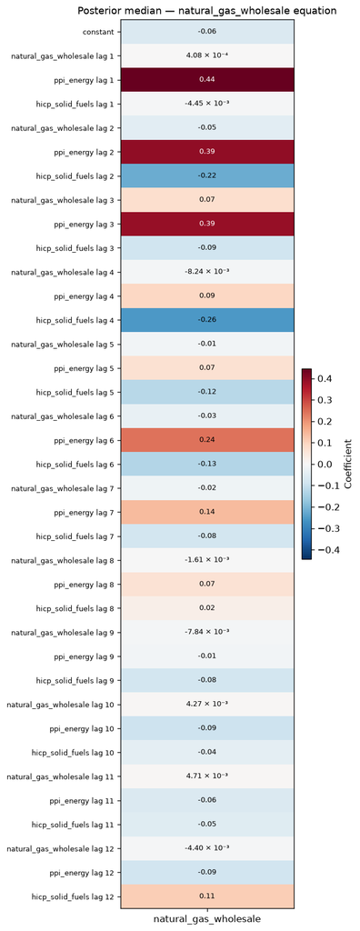

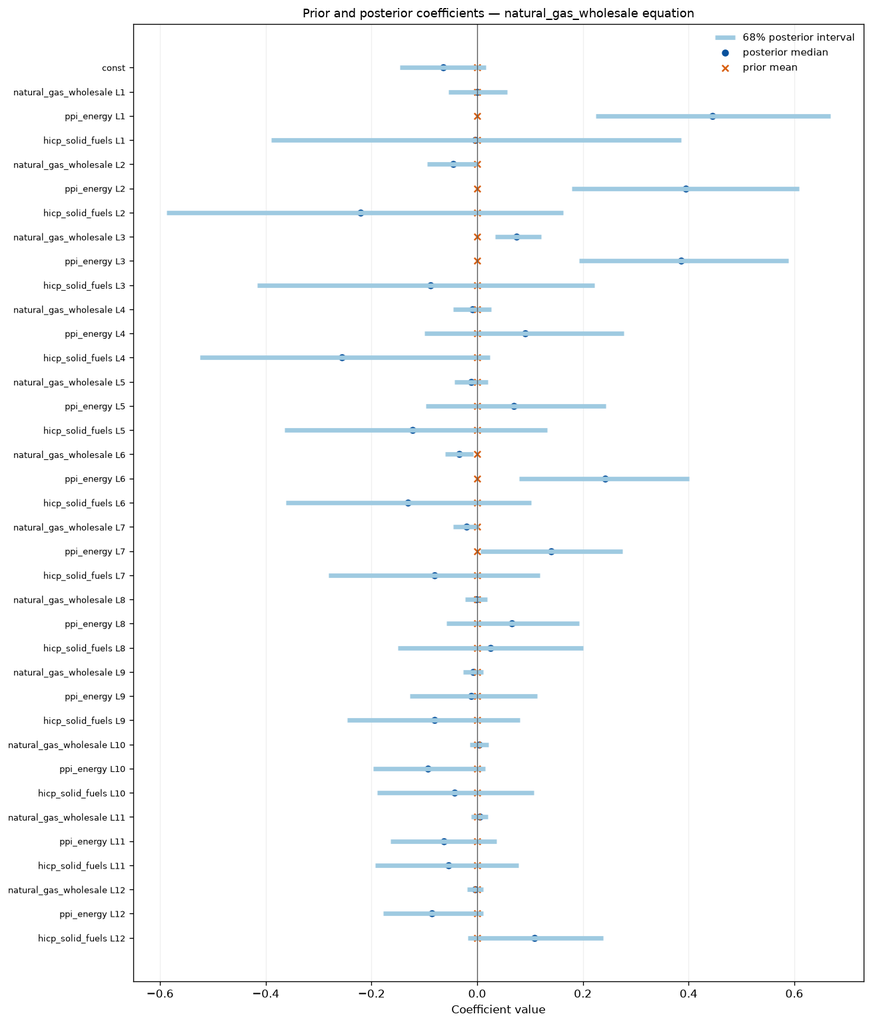

```
ppi_energy equation
```

Posterior coefficients — ppi_energy equation

| regressor | prior_mean | prior_sd | posterior_mean | posterior_median | posterior_sd | q05 | q16 | q84 | q95 | ESS |
| --- | --- | --- | --- | --- | --- | --- | --- | --- | --- | --- |
| const | 0.00 | 8.40 | 0.04 | 0.04 | 0.02 | 0.01 | 0.02 | 0.06 | 0.08 | 1855.18 |
| natural_gas_wholesale L1 | 0.00 | 7.81 × 10⁻³ | 6.68 × 10⁻³ | 6.68 × 10⁻³ | 5.20 × 10⁻³ | -1.81 × 10⁻³ | 1.45 × 10⁻³ | 0.01 | 0.02 | 1828.66 |
| ppi_energy L1 | 0.00 | 0.20 | 0.44 | 0.44 | 0.05 | 0.36 | 0.39 | 0.49 | 0.53 | 2282.93 |
| hicp_solid_fuels L1 | 0.00 | 0.13 | 0.02 | 0.02 | 0.07 | -0.09 | -0.05 | 0.09 | 0.13 | 535.85 |
| natural_gas_wholesale L2 | 0.00 | 3.91 × 10⁻³ | 7.81 × 10⁻⁴ | 7.04 × 10⁻⁴ | 3.56 × 10⁻³ | -4.92 × 10⁻³ | -2.83 × 10⁻³ | 4.36 × 10⁻³ | 6.87 × 10⁻³ | 1925.94 |
| ppi_energy L2 | 0.00 | 0.10 | 0.04 | 0.04 | 0.05 | -0.04 | -6.50 × 10⁻³ | 0.09 | 0.12 | 977.38 |
| hicp_solid_fuels L2 | 0.00 | 0.07 | 0.05 | 0.05 | 0.05 | -0.03 | 4.03 × 10⁻⁴ | 0.11 | 0.14 | 2620.03 |
| natural_gas_wholesale L3 | 0.00 | 2.60 × 10⁻³ | 2.27 × 10⁻³ | 2.30 × 10⁻³ | 2.53 × 10⁻³ | -1.91 × 10⁻³ | -2.71 × 10⁻⁴ | 4.76 × 10⁻³ | 6.33 × 10⁻³ | 1194.18 |
| ppi_energy L3 | 0.00 | 0.07 | 0.08 | 0.08 | 0.04 | 0.01 | 0.04 | 0.13 | 0.16 | 2162.43 |
| hicp_solid_fuels L3 | 0.00 | 0.04 | -0.01 | -0.01 | 0.04 | -0.08 | -0.05 | 0.03 | 0.05 | 1335.18 |
| natural_gas_wholesale L4 | 0.00 | 1.95 × 10⁻³ | -1.46 × 10⁻³ | -1.43 × 10⁻³ | 1.89 × 10⁻³ | -4.61 × 10⁻³ | -3.35 × 10⁻³ | 3.91 × 10⁻⁴ | 1.72 × 10⁻³ | 1533.09 |
| ppi_energy L4 | 0.00 | 0.05 | -0.03 | -0.03 | 0.04 | -0.09 | -0.07 | 2.60 × 10⁻³ | 0.03 | 2207.44 |
| hicp_solid_fuels L4 | 0.00 | 0.03 | 5.92 × 10⁻³ | 5.61 × 10⁻³ | 0.03 | -0.04 | -0.03 | 0.04 | 0.06 | 509.82 |
| natural_gas_wholesale L5 | 0.00 | 1.56 × 10⁻³ | -6.26 × 10⁻⁵ | -4.79 × 10⁻⁵ | 1.49 × 10⁻³ | -2.45 × 10⁻³ | -1.59 × 10⁻³ | 1.42 × 10⁻³ | 2.41 × 10⁻³ | 2524.83 |
| ppi_energy L5 | 0.00 | 0.04 | 0.03 | 0.03 | 0.03 | -0.02 | -2.51 × 10⁻³ | 0.06 | 0.08 | 2166.17 |
| hicp_solid_fuels L5 | 0.00 | 0.03 | -5.85 × 10⁻³ | -6.05 × 10⁻³ | 0.02 | -0.05 | -0.03 | 0.02 | 0.03 | 2256.05 |
| natural_gas_wholesale L6 | 0.00 | 1.30 × 10⁻³ | 4.54 × 10⁻⁴ | 4.27 × 10⁻⁴ | 1.26 × 10⁻³ | -1.60 × 10⁻³ | -7.70 × 10⁻⁴ | 1.72 × 10⁻³ | 2.56 × 10⁻³ | 1837.73 |
| ppi_energy L6 | 0.00 | 0.03 | 0.04 | 0.04 | 0.03 | -5.86 × 10⁻³ | 0.01 | 0.07 | 0.09 | 1083.05 |
| hicp_solid_fuels L6 | 0.00 | 0.02 | -3.95 × 10⁻³ | -3.72 × 10⁻³ | 0.02 | -0.04 | -0.02 | 0.02 | 0.03 | 3000.00 |
| natural_gas_wholesale L7 | 0.00 | 1.12 × 10⁻³ | 1.87 × 10⁻⁴ | 1.92 × 10⁻⁴ | 1.09 × 10⁻³ | -1.64 × 10⁻³ | -9.09 × 10⁻⁴ | 1.27 × 10⁻³ | 1.98 × 10⁻³ | 2788.53 |
| ppi_energy L7 | 0.00 | 0.03 | 0.01 | 0.01 | 0.03 | -0.03 | -0.02 | 0.04 | 0.05 | 2113.29 |
| hicp_solid_fuels L7 | 0.00 | 0.02 | -2.63 × 10⁻³ | -2.39 × 10⁻³ | 0.02 | -0.03 | -0.02 | 0.01 | 0.03 | 3000.00 |
| natural_gas_wholesale L8 | 0.00 | 9.76 × 10⁻⁴ | -9.05 × 10⁻⁵ | -9.38 × 10⁻⁵ | 9.49 × 10⁻⁴ | -1.64 × 10⁻³ | -1.06 × 10⁻³ | 8.58 × 10⁻⁴ | 1.46 × 10⁻³ | 2650.19 |
| ppi_energy L8 | 0.00 | 0.03 | -9.95 × 10⁻³ | -9.46 × 10⁻³ | 0.02 | -0.05 | -0.03 | 0.01 | 0.03 | 2564.62 |
| hicp_solid_fuels L8 | 0.00 | 0.02 | -4.94 × 10⁻³ | -4.94 × 10⁻³ | 0.02 | -0.03 | -0.02 | 0.01 | 0.02 | 2607.10 |
| natural_gas_wholesale L9 | 0.00 | 8.68 × 10⁻⁴ | 8.90 × 10⁻⁵ | 8.95 × 10⁻⁵ | 8.65 × 10⁻⁴ | -1.34 × 10⁻³ | -7.68 × 10⁻⁴ | 9.60 × 10⁻⁴ | 1.52 × 10⁻³ | 3000.00 |
| ppi_energy L9 | 0.00 | 0.02 | -1.10 × 10⁻⁴ | 3.15 × 10⁻⁶ | 0.02 | -0.03 | -0.02 | 0.02 | 0.03 | 2836.53 |
| hicp_solid_fuels L9 | 0.00 | 0.01 | 3.98 × 10⁻⁴ | 2.62 × 10⁻⁴ | 0.01 | -0.02 | -0.01 | 0.01 | 0.02 | 2941.62 |
| natural_gas_wholesale L10 | 0.00 | 7.81 × 10⁻⁴ | -1.27 × 10⁻⁴ | -1.05 × 10⁻⁴ | 7.58 × 10⁻⁴ | -1.37 × 10⁻³ | -8.72 × 10⁻⁴ | 5.97 × 10⁻⁴ | 1.09 × 10⁻³ | 3000.00 |
| ppi_energy L10 | 0.00 | 0.02 | 2.88 × 10⁻³ | 3.43 × 10⁻³ | 0.02 | -0.03 | -0.02 | 0.02 | 0.03 | 2850.70 |
| hicp_solid_fuels L10 | 0.00 | 0.01 | -1.06 × 10⁻³ | -1.33 × 10⁻³ | 0.01 | -0.02 | -0.01 | 0.01 | 0.02 | 2654.76 |
| natural_gas_wholesale L11 | 0.00 | 7.10 × 10⁻⁴ | -1.77 × 10⁻⁴ | -1.67 × 10⁻⁴ | 6.99 × 10⁻⁴ | -1.34 × 10⁻³ | -8.70 × 10⁻⁴ | 5.33 × 10⁻⁴ | 9.65 × 10⁻⁴ | 3000.00 |
| ppi_energy L11 | 0.00 | 0.02 | -5.88 × 10⁻³ | -6.00 × 10⁻³ | 0.02 | -0.03 | -0.02 | 0.01 | 0.02 | 2794.99 |
| hicp_solid_fuels L11 | 0.00 | 0.01 | 3.08 × 10⁻³ | 3.13 × 10⁻³ | 0.01 | -0.02 | -9.02 × 10⁻³ | 0.02 | 0.02 | 2370.15 |
| natural_gas_wholesale L12 | 0.00 | 6.51 × 10⁻⁴ | 7.54 × 10⁻⁵ | 8.59 × 10⁻⁵ | 6.45 × 10⁻⁴ | -1.01 × 10⁻³ | -5.60 × 10⁻⁴ | 7.05 × 10⁻⁴ | 1.15 × 10⁻³ | 3000.00 |
| ppi_energy L12 | 0.00 | 0.02 | -0.01 | -0.01 | 0.02 | -0.04 | -0.03 | 4.62 × 10⁻³ | 0.01 | 2547.95 |
| hicp_solid_fuels L12 | 0.00 | 0.01 | -4.71 × 10⁻⁴ | -6.20 × 10⁻⁴ | 0.01 | -0.02 | -0.01 | 0.01 | 0.02 | 2888.21 |

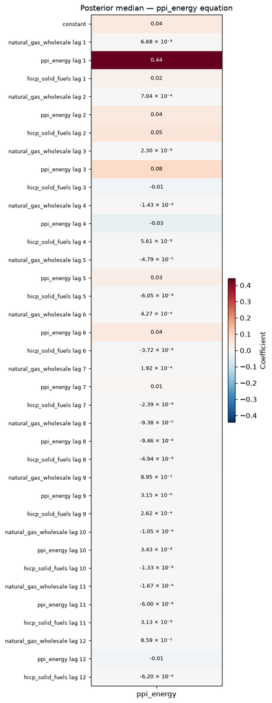

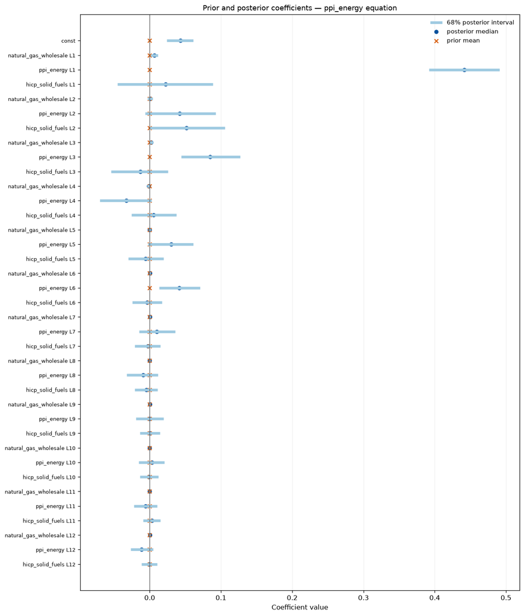

```
hicp_solid_fuels equation
```

Posterior coefficients — hicp_solid_fuels equation

| regressor | prior_mean | prior_sd | posterior_mean | posterior_median | posterior_sd | q05 | q16 | q84 | q95 | ESS |
| --- | --- | --- | --- | --- | --- | --- | --- | --- | --- | --- |
| const | 0.00 | 6.30 | 0.04 | 0.04 | 0.01 | 0.03 | 0.03 | 0.06 | 0.06 | 694.58 |
| natural_gas_wholesale L1 | 0.00 | 5.86 × 10⁻³ | 1.48 × 10⁻³ | 1.50 × 10⁻³ | 4.05 × 10⁻³ | -5.13 × 10⁻³ | -2.61 × 10⁻³ | 5.49 × 10⁻³ | 8.12 × 10⁻³ | 1664.18 |
| ppi_energy L1 | 0.00 | 0.08 | 0.05 | 0.05 | 0.03 | 9.14 × 10⁻³ | 0.03 | 0.08 | 0.09 | 696.52 |
| hicp_solid_fuels L1 | 0.00 | 0.20 | 0.31 | 0.31 | 0.06 | 0.21 | 0.25 | 0.37 | 0.42 | 653.00 |
| natural_gas_wholesale L2 | 0.00 | 2.93 × 10⁻³ | 1.73 × 10⁻³ | 1.69 × 10⁻³ | 2.65 × 10⁻³ | -2.61 × 10⁻³ | -9.25 × 10⁻⁴ | 4.46 × 10⁻³ | 6.07 × 10⁻³ | 1966.84 |
| ppi_energy L2 | 0.00 | 0.04 | 6.93 × 10⁻³ | 6.42 × 10⁻³ | 0.02 | -0.03 | -0.01 | 0.03 | 0.04 | 909.71 |
| hicp_solid_fuels L2 | 0.00 | 0.10 | 0.12 | 0.12 | 0.05 | 0.03 | 0.07 | 0.16 | 0.20 | 1647.36 |
| natural_gas_wholesale L3 | 0.00 | 1.95 × 10⁻³ | 1.10 × 10⁻³ | 1.08 × 10⁻³ | 1.85 × 10⁻³ | -1.93 × 10⁻³ | -7.72 × 10⁻⁴ | 2.95 × 10⁻³ | 4.18 × 10⁻³ | 2585.24 |
| ppi_energy L3 | 0.00 | 0.03 | -1.32 × 10⁻³ | -1.23 × 10⁻³ | 0.02 | -0.03 | -0.02 | 0.02 | 0.03 | 2227.02 |
| hicp_solid_fuels L3 | 0.00 | 0.07 | 0.03 | 0.03 | 0.04 | -0.05 | -0.02 | 0.07 | 0.10 | 1303.87 |
| natural_gas_wholesale L4 | 0.00 | 1.47 × 10⁻³ | 1.44 × 10⁻⁵ | 2.75 × 10⁻⁵ | 1.40 × 10⁻³ | -2.29 × 10⁻³ | -1.34 × 10⁻³ | 1.36 × 10⁻³ | 2.35 × 10⁻³ | 2746.70 |
| ppi_energy L4 | 0.00 | 0.02 | 4.36 × 10⁻⁴ | 4.80 × 10⁻⁴ | 0.01 | -0.02 | -0.01 | 0.02 | 0.02 | 2025.82 |
| hicp_solid_fuels L4 | 0.00 | 0.05 | 0.02 | 0.02 | 0.04 | -0.04 | -0.02 | 0.06 | 0.08 | 1690.22 |
| natural_gas_wholesale L5 | 0.00 | 1.17 × 10⁻³ | 3.38 × 10⁻⁴ | 3.18 × 10⁻⁴ | 1.14 × 10⁻³ | -1.48 × 10⁻³ | -7.85 × 10⁻⁴ | 1.50 × 10⁻³ | 2.22 × 10⁻³ | 2688.96 |
| ppi_energy L5 | 0.00 | 0.02 | 2.28 × 10⁻³ | 2.10 × 10⁻³ | 0.01 | -0.02 | -0.01 | 0.02 | 0.02 | 2220.89 |
| hicp_solid_fuels L5 | 0.00 | 0.04 | -7.43 × 10⁻³ | -7.42 × 10⁻³ | 0.03 | -0.06 | -0.04 | 0.02 | 0.05 | 1760.82 |
| natural_gas_wholesale L6 | 0.00 | 9.77 × 10⁻⁴ | 3.48 × 10⁻⁴ | 3.42 × 10⁻⁴ | 9.73 × 10⁻⁴ | -1.27 × 10⁻³ | -5.99 × 10⁻⁴ | 1.34 × 10⁻³ | 1.95 × 10⁻³ | 2330.56 |
| ppi_energy L6 | 0.00 | 0.01 | 6.88 × 10⁻³ | 6.89 × 10⁻³ | 0.01 | -0.01 | -4.20 × 10⁻³ | 0.02 | 0.03 | 2277.97 |
| hicp_solid_fuels L6 | 0.00 | 0.03 | 9.96 × 10⁻³ | 9.80 × 10⁻³ | 0.03 | -0.04 | -0.02 | 0.04 | 0.06 | 1872.78 |
| natural_gas_wholesale L7 | 0.00 | 8.37 × 10⁻⁴ | -4.86 × 10⁻⁵ | -4.28 × 10⁻⁵ | 8.05 × 10⁻⁴ | -1.38 × 10⁻³ | -8.50 × 10⁻⁴ | 7.57 × 10⁻⁴ | 1.27 × 10⁻³ | 2741.52 |
| ppi_energy L7 | 0.00 | 0.01 | 5.10 × 10⁻³ | 5.33 × 10⁻³ | 9.69 × 10⁻³ | -0.01 | -4.36 × 10⁻³ | 0.01 | 0.02 | 2277.28 |
| hicp_solid_fuels L7 | 0.00 | 0.03 | -2.90 × 10⁻³ | -2.56 × 10⁻³ | 0.03 | -0.04 | -0.03 | 0.02 | 0.04 | 2118.39 |
| natural_gas_wholesale L8 | 0.00 | 7.33 × 10⁻⁴ | 1.10 × 10⁻⁴ | 1.20 × 10⁻⁴ | 7.36 × 10⁻⁴ | -1.10 × 10⁻³ | -6.29 × 10⁻⁴ | 8.47 × 10⁻⁴ | 1.34 × 10⁻³ | 3000.00 |
| ppi_energy L8 | 0.00 | 9.38 × 10⁻³ | 3.50 × 10⁻³ | 3.66 × 10⁻³ | 8.71 × 10⁻³ | -0.01 | -5.15 × 10⁻³ | 0.01 | 0.02 | 2537.09 |
| hicp_solid_fuels L8 | 0.00 | 0.03 | 1.64 × 10⁻³ | 1.46 × 10⁻³ | 0.02 | -0.03 | -0.02 | 0.02 | 0.04 | 2681.77 |
| natural_gas_wholesale L9 | 0.00 | 6.51 × 10⁻⁴ | 1.44 × 10⁻⁴ | 1.53 × 10⁻⁴ | 6.47 × 10⁻⁴ | -9.31 × 10⁻⁴ | -4.77 × 10⁻⁴ | 7.71 × 10⁻⁴ | 1.22 × 10⁻³ | 2821.49 |
| ppi_energy L9 | 0.00 | 8.34 × 10⁻³ | 7.67 × 10⁻³ | 7.67 × 10⁻³ | 7.94 × 10⁻³ | -5.64 × 10⁻³ | -3.35 × 10⁻⁴ | 0.02 | 0.02 | 2349.31 |
| hicp_solid_fuels L9 | 0.00 | 0.02 | 0.01 | 0.01 | 0.02 | -0.02 | -8.72 × 10⁻³ | 0.03 | 0.04 | 1963.01 |
| natural_gas_wholesale L10 | 0.00 | 5.86 × 10⁻⁴ | 3.85 × 10⁻⁶ | 3.24 × 10⁻⁶ | 5.89 × 10⁻⁴ | -9.89 × 10⁻⁴ | -5.68 × 10⁻⁴ | 5.87 × 10⁻⁴ | 9.67 × 10⁻⁴ | 2783.92 |
| ppi_energy L10 | 0.00 | 7.50 × 10⁻³ | -7.81 × 10⁻⁴ | -8.82 × 10⁻⁴ | 7.09 × 10⁻³ | -0.01 | -7.80 × 10⁻³ | 6.34 × 10⁻³ | 0.01 | 2757.58 |
| hicp_solid_fuels L10 | 0.00 | 0.02 | 8.28 × 10⁻³ | 8.41 × 10⁻³ | 0.02 | -0.02 | -9.98 × 10⁻³ | 0.03 | 0.04 | 2396.80 |
| natural_gas_wholesale L11 | 0.00 | 5.33 × 10⁻⁴ | 5.40 × 10⁻⁵ | 5.04 × 10⁻⁵ | 5.24 × 10⁻⁴ | -8.09 × 10⁻⁴ | -4.64 × 10⁻⁴ | 5.85 × 10⁻⁴ | 9.35 × 10⁻⁴ | 2815.41 |
| ppi_energy L11 | 0.00 | 6.82 × 10⁻³ | 1.67 × 10⁻³ | 1.71 × 10⁻³ | 6.55 × 10⁻³ | -9.19 × 10⁻³ | -4.93 × 10⁻³ | 8.16 × 10⁻³ | 0.01 | 3000.00 |
| hicp_solid_fuels L11 | 0.00 | 0.02 | -1.59 × 10⁻³ | -1.67 × 10⁻³ | 0.02 | -0.03 | -0.02 | 0.02 | 0.03 | 2041.84 |
| natural_gas_wholesale L12 | 0.00 | 4.88 × 10⁻⁴ | 5.36 × 10⁻⁵ | 4.66 × 10⁻⁵ | 4.77 × 10⁻⁴ | -7.32 × 10⁻⁴ | -4.15 × 10⁻⁴ | 5.25 × 10⁻⁴ | 8.38 × 10⁻⁴ | 2760.15 |
| ppi_energy L12 | 0.00 | 6.25 × 10⁻³ | 3.13 × 10⁻³ | 3.27 × 10⁻³ | 6.00 × 10⁻³ | -7.01 × 10⁻³ | -2.78 × 10⁻³ | 8.88 × 10⁻³ | 0.01 | 2739.03 |
| hicp_solid_fuels L12 | 0.00 | 0.02 | -7.61 × 10⁻³ | -7.79 × 10⁻³ | 0.02 | -0.03 | -0.02 | 7.15 × 10⁻³ | 0.02 | 2101.72 |

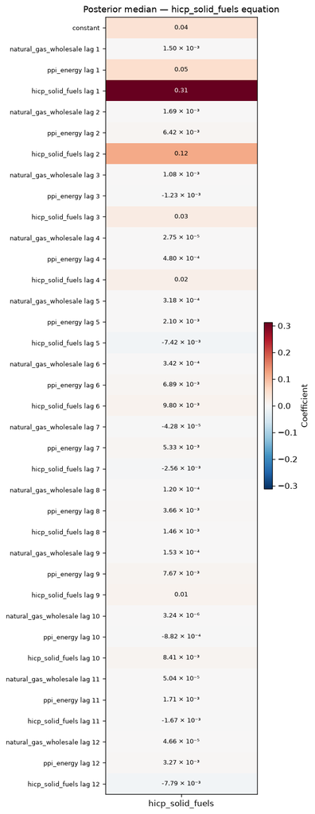

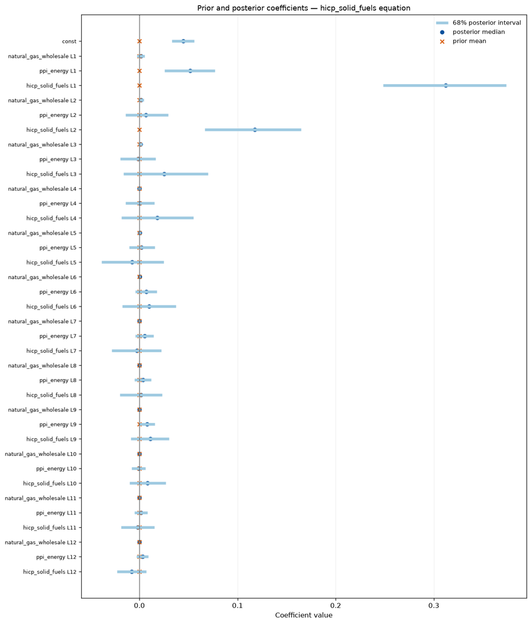

```python
coefficient_tables = coefficient_posterior_tables(result)
for equation in VARIABLES:
    print()
    print(f"{equation} equation")
    display(style_numeric_table(
        coefficient_tables[equation],
        caption=f"Posterior coefficients — {equation} equation",
    ))
    plot_coefficient_heatmap(result, equation=equation)
    plot_shrinkage_comparison(result, equations=[equation])
    plt.show()
```

### 6.2 Stochastic volatility and transitory outliers

Dates with posterior outlier probability at least 50%

| date |  | posterior_probability |
| --- | --- | --- |
| 2022-01-01 | ppi_energy | 0.96 |
| 2026-03-01 | ppi_energy | 0.89 |
| 2003-10-01 | hicp_solid_fuels | 0.64 |
| 2001-07-01 | natural_gas_wholesale | 0.57 |

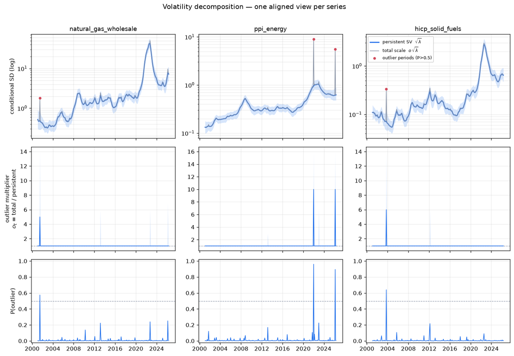

```python
outlier_probability = posterior_outlier_probability(result)
important_outliers = (
    outlier_probability.stack()
    .rename("posterior_probability")
    .loc[lambda series: series >= 0.50]
    .sort_values(ascending=False)
    .to_frame()
)
display(style_numeric_table(
    important_outliers.head(30),
    caption="Dates with posterior outlier probability at least 50%",
))
plot_volatility_decomposition(result)
plt.show()
```

### 6.3 Standardized structural residuals

Standardized structural-residual diagnostics

| variable | mean | sd | skewness | excess_kurtosis | acf_1 | maximum_absolute |
| --- | --- | --- | --- | --- | --- | --- |
| natural_gas_wholesale | 0.02 | 0.94 | 0.05 | -0.09 | 0.01 | 2.80 |
| ppi_energy | 3.44 × 10⁻³ | 0.98 | -0.15 | 0.28 | 3.11 × 10⁻³ | 2.74 |
| hicp_solid_fuels | 0.01 | 0.95 | 0.18 | -0.09 | 7.26 × 10⁻³ | 2.67 |

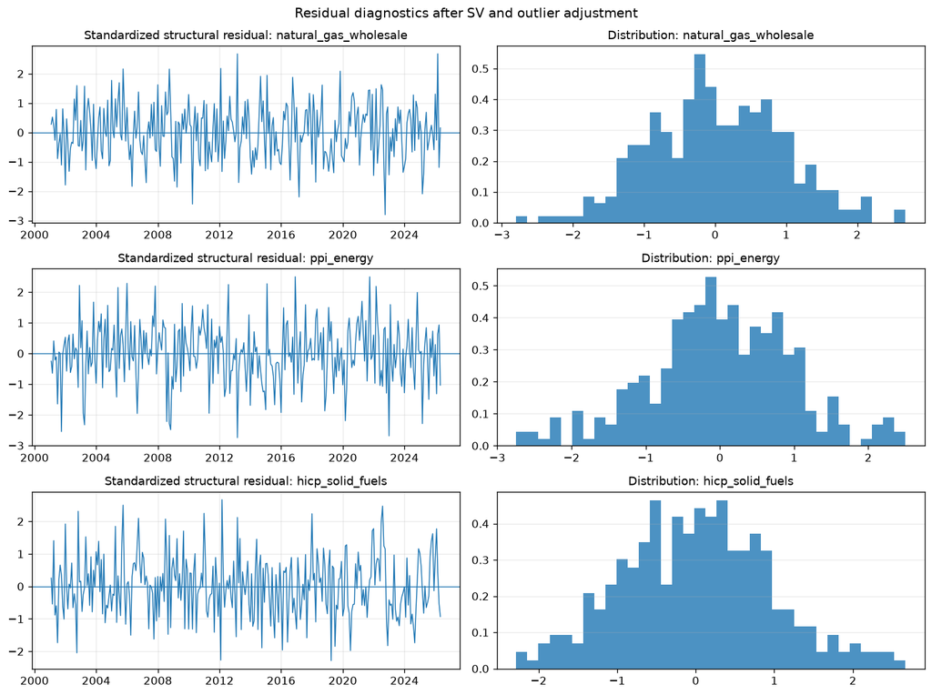

```python
display(style_numeric_table(
    residual_diagnostic_table(result),
    caption="Standardized structural-residual diagnostics",
))
plot_standardized_residuals(result)
plt.show()
```

## 7. Ragged-edge nowcast and forecasts

```
Forecast origin: 2026-08-01
Forecast horizon used: 4 months
```

Ragged-edge nowcast — hicp_solid_fuels

| date | status | observed | q05 | q16 | median | q84 | q95 |
| --- | --- | --- | --- | --- | --- | --- | --- |
| 2026-07-01 | nowcast | — | 104.69 | 105.59 | 106.52 | 107.48 | 108.31 |
| 2026-08-01 | nowcast | — | 103.73 | 105.18 | 106.73 | 108.26 | 110.26 |

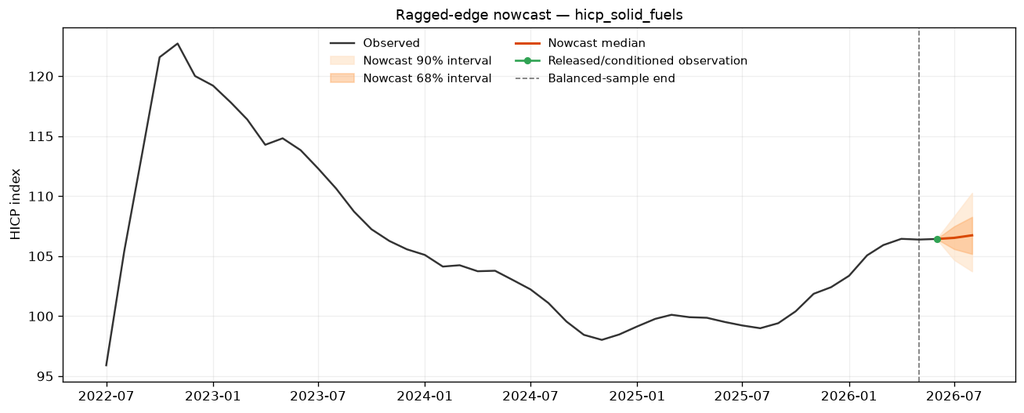

```python
FORECAST_ORIGIN = prep["last_calendar_date"]
MONTHS_TO_YEAR_END = 12 - FORECAST_ORIGIN.month
if MONTHS_TO_YEAR_END == 0:
    MONTHS_TO_YEAR_END = 12
H = max(3, MONTHS_TO_YEAR_END)
FORECAST_DRAWS = min(1_000, result["n_draws"])

forecast_unconditional = forecast_bvar_sv_outlier(
    result,
    H=H,
    n_draws=FORECAST_DRAWS,
    simulate_future_outliers=True,
    seed=2026,
)

print(f"Forecast origin: {FORECAST_ORIGIN.date()}")
print(f"Forecast horizon used: {H} months")

nowcast_table = nowcast_summary_table(
    forecast_unconditional,
    observed_levels=levels,
    variable=TARGET,
    missing_only=True,
)
if nowcast_table.empty:
    print(f"No missing {TARGET} observation is present in the ragged edge.")
else:
    display(style_numeric_table(
        nowcast_table,
        caption=f"Ragged-edge nowcast — {TARGET}",
    ))
plot_nowcast_fan(
    forecast_unconditional,
    historical_levels=levels,
    variable=TARGET,
    ylabel=UNITS[TARGET],
)
plt.show()
```

Unconditional level forecast — natural_gas_wholesale (EUR/MWh)

| horizon | months_ahead | target_date | q05 | q16 | median | q84 | q95 |
| --- | --- | --- | --- | --- | --- | --- | --- |
| 1 month | 1.00 | 2026-09-01 | 27.11 | 46.51 | 58.53 | 69.79 | 92.37 |
| 3 months | 3.00 | 2026-11-01 | 17.46 | 43.61 | 62.78 | 81.20 | 111.15 |
| End of 2026 | 4.00 | 2026-12-01 | 12.23 | 41.88 | 63.93 | 84.72 | 122.07 |

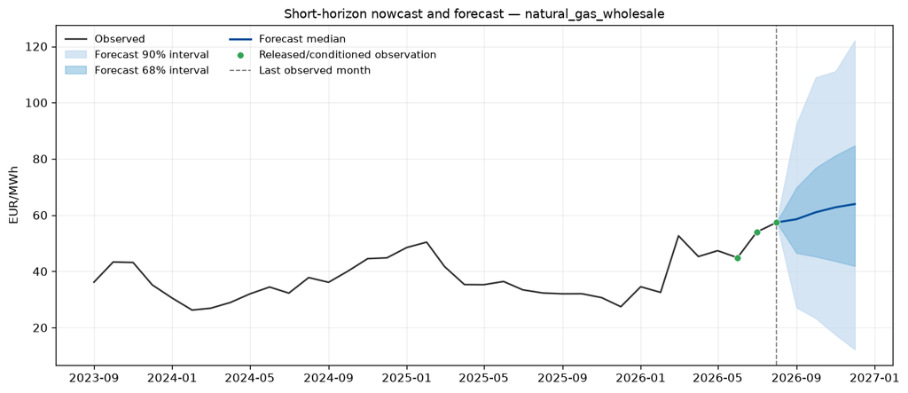

Unconditional level forecast — ppi_energy (Index)

| horizon | months_ahead | target_date | q05 | q16 | median | q84 | q95 |
| --- | --- | --- | --- | --- | --- | --- | --- |
| 1 month | 1.00 | 2026-09-01 | 121.18 | 129.31 | 135.16 | 141.62 | 149.44 |
| 3 months | 3.00 | 2026-11-01 | 117.86 | 128.57 | 136.48 | 144.86 | 156.18 |
| End of 2026 | 4.00 | 2026-12-01 | 116.15 | 127.90 | 137.14 | 146.43 | 162.08 |

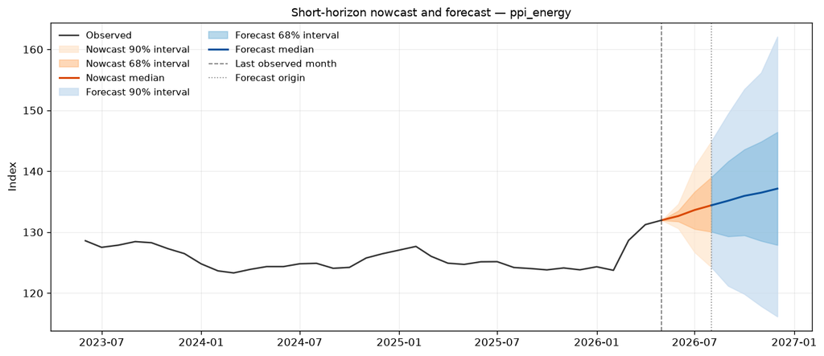

Unconditional level forecast — hicp_solid_fuels (HICP index)

| horizon | months_ahead | target_date | q05 | q16 | median | q84 | q95 |
| --- | --- | --- | --- | --- | --- | --- | --- |
| 1 month | 1.00 | 2026-09-01 | 102.62 | 104.79 | 106.98 | 109.25 | 112.06 |
| 3 months | 3.00 | 2026-11-01 | 101.06 | 104.47 | 107.57 | 111.22 | 115.84 |
| End of 2026 | 4.00 | 2026-12-01 | 100.33 | 104.20 | 107.92 | 112.04 | 117.97 |

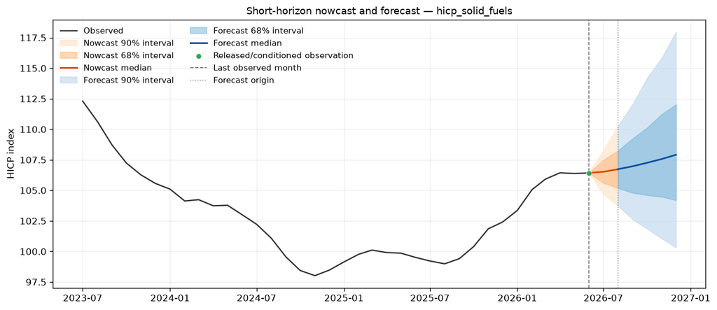

```python
for variable in VARIABLES:
    table = forecast_horizon_table(forecast_unconditional, variable)
    display(style_numeric_table(
        table,
        caption=f"Unconditional level forecast — {variable} ({UNITS[variable]})",
    ))
    plot_short_forecast_fan(
        forecast_unconditional,
        historical_levels=levels,
        variable=variable,
        ylabel=UNITS[variable],
    )
    plt.show()
```

### 7.1 Conditional wholesale-gas scenario

The future wholesale natural-gas level is fixed at 10% above its latest observed value. This is a scenario comparison; the other variables remain unconstrained.

```
Maximum absolute wholesale-gas condition error: 7.11 × 10⁻¹³
```

Conditional hicp_solid_fuels forecast — wholesale gas +10%

| horizon | months_ahead | target_date | q05 | q16 | median | q84 | q95 |
| --- | --- | --- | --- | --- | --- | --- | --- |
| 1 month | 1.00 | 2026-09-01 | 102.60 | 104.71 | 107.01 | 109.20 | 112.34 |
| 3 months | 3.00 | 2026-11-01 | 101.04 | 104.56 | 107.60 | 111.21 | 115.80 |
| End of 2026 | 4.00 | 2026-12-01 | 100.65 | 104.45 | 107.98 | 112.19 | 117.66 |

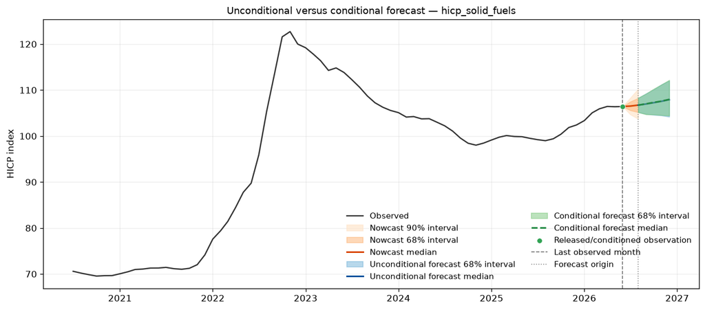

```python
last_wholesale_level = levels["natural_gas_wholesale"].dropna().iloc[-1]
wholesale_up_10 = np.full(H, 1.10 * last_wholesale_level)

forecast_gas_up_10 = forecast_bvar_sv_outlier(
    result,
    H=H,
    level_conditions={"natural_gas_wholesale": wholesale_up_10},
    n_draws=FORECAST_DRAWS,
    simulate_future_outliers=True,
    seed=2026,
)

condition_error = np.max(np.abs(
    forecast_gas_up_10["future_level_paths"][:, :, VARIABLES.index("natural_gas_wholesale")]
    - wholesale_up_10[None, :]
))
print(f"Maximum absolute wholesale-gas condition error: {format_number(condition_error)}")

display(style_numeric_table(
    forecast_horizon_table(forecast_gas_up_10, TARGET),
    caption=f"Conditional {TARGET} forecast — wholesale gas +10%",
))
plot_forecast_comparison(
    forecast_unconditional,
    forecast_gas_up_10,
    historical_levels=levels,
    variable=TARGET,
    ylabel=UNITS[TARGET],
)
plt.show()
```

### 7.2 Conditional PPI Energy scenario

The future PPI Energy level is fixed at 10% above its latest observed value, while wholesale gas and the HICP target remain unconstrained.

```
Maximum absolute PPI condition error: 5.12 × 10⁻¹³
```

Conditional hicp_solid_fuels forecast — PPI Energy +10%

| horizon | months_ahead | target_date | q05 | q16 | median | q84 | q95 |
| --- | --- | --- | --- | --- | --- | --- | --- |
| 1 month | 1.00 | 2026-09-01 | 102.84 | 105.33 | 107.35 | 109.44 | 111.46 |
| 3 months | 3.00 | 2026-11-01 | 101.75 | 105.42 | 108.34 | 111.39 | 115.06 |
| End of 2026 | 4.00 | 2026-12-01 | 101.12 | 105.35 | 108.68 | 112.17 | 116.73 |

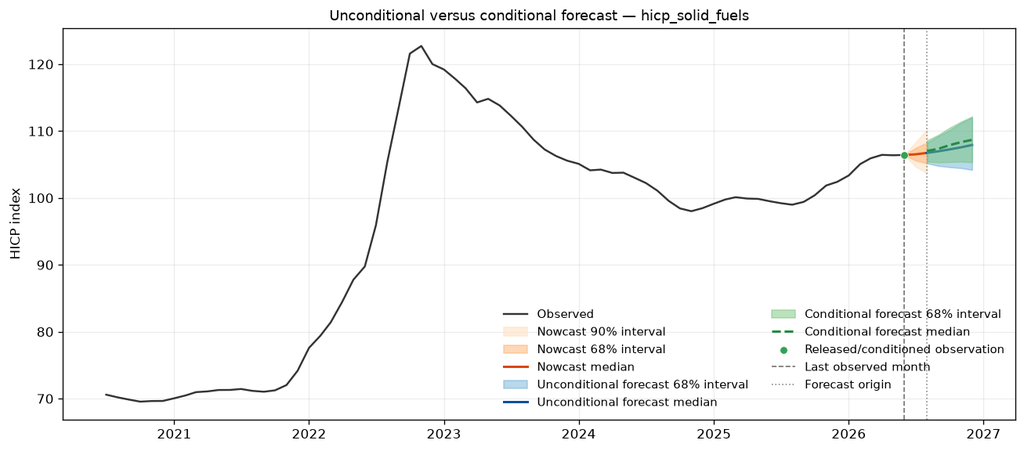

```python
last_ppi_level = levels["ppi_energy"].dropna().iloc[-1]
ppi_up_10 = np.full(H, 1.10 * last_ppi_level)

forecast_ppi_up_10 = forecast_bvar_sv_outlier(
    result,
    H=H,
    level_conditions={"ppi_energy": ppi_up_10},
    n_draws=FORECAST_DRAWS,
    simulate_future_outliers=True,
    seed=2026,
)

condition_error = np.max(np.abs(
    forecast_ppi_up_10["future_level_paths"][:, :, VARIABLES.index("ppi_energy")]
    - ppi_up_10[None, :]
))
print(f"Maximum absolute PPI condition error: {format_number(condition_error)}")

display(style_numeric_table(
    forecast_horizon_table(forecast_ppi_up_10, TARGET),
    caption=f"Conditional {TARGET} forecast — PPI Energy +10%",
))
plot_forecast_comparison(
    forecast_unconditional,
    forecast_ppi_up_10,
    historical_levels=levels,
    variable=TARGET,
    ylabel=UNITS[TARGET],
)
plt.show()
```

### 7.3 HICP solid fuels level and year-on-year inflation

HICP solid fuels index forecast

| horizon | months_ahead | target_date | q05 | q16 | median | q84 | q95 |
| --- | --- | --- | --- | --- | --- | --- | --- |
| 1 month | 1.00 | 2026-09-01 | 102.62 | 104.79 | 106.98 | 109.25 | 112.06 |
| 3 months | 3.00 | 2026-11-01 | 101.06 | 104.47 | 107.57 | 111.22 | 115.84 |
| End of 2026 | 4.00 | 2026-12-01 | 100.33 | 104.20 | 107.92 | 112.04 | 117.97 |

HICP solid fuels year-on-year inflation forecast (%)

| horizon | months_ahead | target_date | q05 | q16 | median | q84 | q95 |
| --- | --- | --- | --- | --- | --- | --- | --- |
| 1 month | 1.00 | 2026-09-01 | 3.23 | 5.41 | 7.61 | 9.90 | 12.73 |
| 3 months | 3.00 | 2026-11-01 | -0.79 | 2.56 | 5.60 | 9.19 | 13.73 |
| End of 2026 | 4.00 | 2026-12-01 | -2.03 | 1.75 | 5.38 | 9.40 | 15.19 |

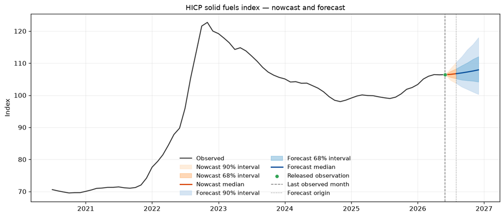

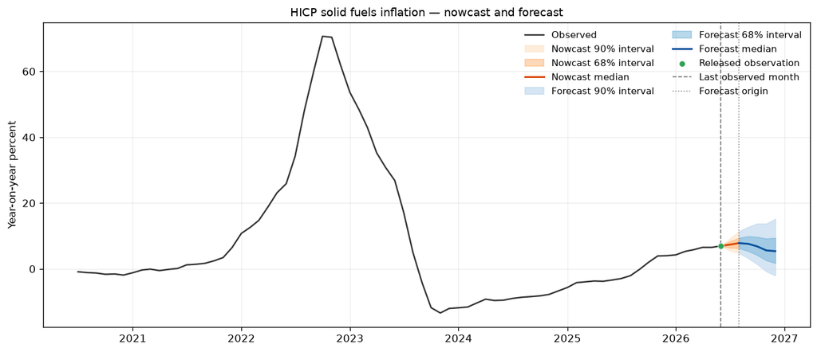

```python
hicp_unconditional = forecast_hicp_component(
    forecast_unconditional,
    result,
    component=COMPONENT,
)
hicp_gas_up_10 = forecast_hicp_component(
    forecast_gas_up_10,
    result,
    component=COMPONENT,
)
hicp_ppi_up_10 = forecast_hicp_component(
    forecast_ppi_up_10,
    result,
    component=COMPONENT,
)

display(style_numeric_table(
    path_horizon_table(
        hicp_unconditional["future_hicp_level_paths"],
        hicp_unconditional["future_dates"],
        forecast_unconditional["last_calendar_date"],
    ),
    caption=f"HICP {SPEC['label']} index forecast",
))
display(style_numeric_table(
    path_horizon_table(
        hicp_unconditional["future_hicp_yoy_paths"],
        hicp_unconditional["future_dates"],
        forecast_unconditional["last_calendar_date"],
    ),
    caption=f"HICP {SPEC['label']} year-on-year inflation forecast (%)",
))

plot_hicp_forecast_fan(
    hicp_unconditional,
    kind="level",
    component_label=SPEC["label"],
)
plot_hicp_forecast_fan(
    hicp_unconditional,
    kind="yoy",
    component_label=SPEC["label"],
)
plt.show()
```

## 8. Structural analysis

The recursive ordering is wholesale natural gas, PPI Energy, then the HICP component. It therefore treats the commodity-price block as contemporaneously upstream of the consumer-price target. The alternative sign-restricted identification only imposes a positive own impact for each named shock.